# Reproducible Research: Peer Assessment 1

## Loading and preprocessing the data

And also displaying the head output

```r
activity <- read.csv("./activity.csv")

head(activity)
```

```
##   steps       date interval
## 1    NA 2012-10-01        0
## 2    NA 2012-10-01        5
## 3    NA 2012-10-01       10
## 4    NA 2012-10-01       15
## 5    NA 2012-10-01       20
## 6    NA 2012-10-01       25
```

## What is mean total number of steps taken per day?

Using `aggregate()` (automatically sorts them ito the day category) and applying a sum function for each class

```r
total_steps_per_day <- aggregate(activity$steps ~ activity$date, FUN = function(x) sum(x, na.rm = TRUE))
head(total_steps_per_day)
```

```
##   activity$date activity$steps
## 1    2012-10-02            126
## 2    2012-10-03          11352
## 3    2012-10-04          12116
## 4    2012-10-05          13294
## 5    2012-10-06          15420
## 6    2012-10-07          11015
```

constructing a histogram to display the results; using `ggplot2`

[figure not shown]

calculating and reporting the mean and median steps for every day

```r
summary(total_steps_per_day)
```

```
##      date            stepsPerDay
##  Length:53          Min.   :   41
##  Class :character   1st Qu.: 8841
##  Mode  :character   Median :10765
##                     Mean   :10766
##                     3rd Qu.:13294
##                     Max.   :21194
```

the mean number of steps is **10766** and the median number of steps waled each day is **10765**

## What is the average daily activity pattern?

aggregating the data set according to the 5 min window

```r
mean_steps_per_interval<- aggregate(activity$steps ~ activity$interval, FUN = function(x) mean(x, na.rm = TRUE))
head(mean_steps_per_interval)
```

```
##   activity$interval activity$steps
## 1                 0      1.7169811
## 2                 5      0.3396226
## 3                10      0.1320755
## 4                15      0.1509434
## 5                20      0.0754717
## 6                25      2.0943396
```

creating the plot

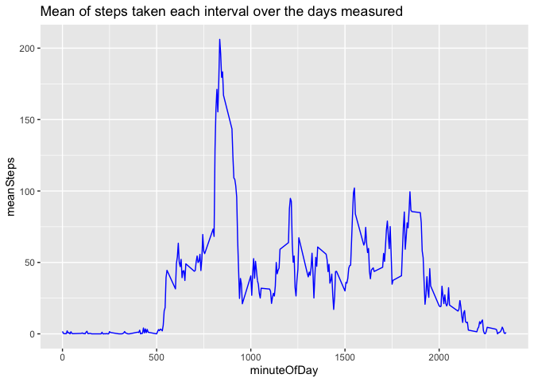

```r
## change the names so they appear better in the graph and also
names(mean_steps_per_interval) <- c("minuteOfDay", "meanSteps")

# construct the histogram in ggplot2
#define the data series
ggplot(mean_steps_per_interval, aes(x =minuteOfDay, y=meanSteps )) +
    #edit the visuals: colors, title
    geom_line(color = "blue")+
    labs(title = "Mean of steps taken each interval over the days measured")
```

```r
colMax <- function(x) sapply(x, max, na.rm = TRUE)

colMax(mean_steps_per_interval)
```

```
## minuteOfDay   meanSteps
##   2355.0000    206.1698
```

## Imputing missing values

finding total number of NA - lines with missing data

```r
sum(is.na(activity))
```

```
## [1] 2304
```

there’s **2304** rows with NA fields of data

```r
#finding the median of the steps take in each interval
median_steps_per_interval<- aggregate(activity$steps ~ activity$interval, FUN = function(x) mean(x, na.rm = TRUE))

#replacing them
data_filled <- activity

# Loop through each column and replace NAs with the median values
for (i in 1:nrow(data_filled)) {
  if (is.na(data_filled$steps[i])) {  # Check if 'steps' column has NA for the current row
    # Find the corresponding 'interval' value for this row
    interval_value <- data_filled$interval[i]

    # Find the median value for this 'interval' in the mean_steps_per_interval dataframe
    median_value <- median_steps_per_interval$`activity$steps`[
      median_steps_per_interval$`activity$interval` == interval_value
    ]
    # Replace the missing value with the median for the corresponding 'interval'
    data_filled$steps[i] <- median_value
  }
}


head(data_filled)
```

```
##       steps       date interval
## 1 1.7169811 2012-10-01        0
## 2 0.3396226 2012-10-01        5
## 3 0.1320755 2012-10-01       10
## 4 0.1509434 2012-10-01       15
## 5 0.0754717 2012-10-01       20
## 6 2.0943396 2012-10-01       25
```

comparinfg the filled in data to the one with NAs

```r
total_steps_per_day_filled <- aggregate(data_filled$steps ~ data_filled$date, FUN = function(x) sum(x, na.rm = TRUE))
head(total_steps_per_day_filled)
```

```
##   data_filled$date data_filled$steps
## 1       2012-10-01          10766.19
## 2       2012-10-02            126.00
## 3       2012-10-03          11352.00
## 4       2012-10-04          12116.00
## 5       2012-10-05          13294.00
## 6       2012-10-06          15420.00
```

constructing a histogram to display the results; using `ggplot2`

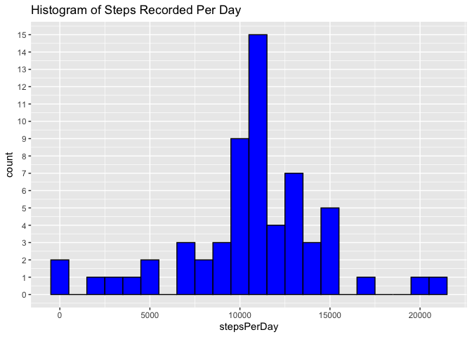

```r
# import ggplot2
library(ggplot2)

## change the names so they appear better in the graph and also
names(total_steps_per_day_filled) <- c("date", "stepsPerDay")

# construcdt the histogram in ggplot2
#define the data series
ggplot(total_steps_per_day_filled, aes(x = stepsPerDay)) +
    #edit the visuals: colors, title and make the Y axis make sense (goes up by 1)
  geom_histogram(color = "black", fill = "blue", binwidth = 1000) +
  labs(title = "Histogram of Steps Recorded Per Day")+
  scale_y_continuous(breaks = seq(0, max(total_steps_per_day_filled$stepsPerDay), by = 1))
```

calculating and reporting the mean and median steps for every day

```r
summary(total_steps_per_day_filled)
```

```
##      date            stepsPerDay
##  Length:61          Min.   :   41
##  Class :character   1st Qu.: 9819
##  Mode  :character   Median :10766
##                     Mean   :10766
##                     3rd Qu.:12811
##                     Max.   :21194
```

the mean number of steps is **10766** and the median number of steps waled each day is **10766**

altogether the data is now more skewed towards the mean number of steps each day

## Are there differences in activity patterns between weekdays and weekends?

```r
# convert date column into Date format
data_filled$date <- as.Date(data_filled$date)

# Create a new variable 'weekday' indicating 'weekday' or 'weekend'
data_filled$weekday <- ifelse(weekdays(data_filled$date) %in% c("Saturday", "Sunday"), "weekend", "weekday")

# Convert the 'weekday' variable to a factor
data_filled$weekday <- factor(data_filled$weekday, levels = c("weekday", "weekend"))

# Check the first few rows to confirm
head(data_filled)
```

```
##       steps       date interval weekday
## 1 1.7169811 2012-10-01        0 weekday
## 2 0.3396226 2012-10-01        5 weekday
## 3 0.1320755 2012-10-01       10 weekday
## 4 0.1509434 2012-10-01       15 weekday
## 5 0.0754717 2012-10-01       20 weekday
## 6 2.0943396 2012-10-01       25 weekday
```

Calculate the data for each categry

```r
#calculate mean steps for weekends
weekend_data <- data_filled[data_filled$weekday == "weekend", ]
mean_steps_weekend<- aggregate(weekend_data$steps ~ weekend_data$interval, FUN = function(x) mean(x, na.rm = TRUE))
names(mean_steps_weekend) <- c("minuteOfDay", "meanSteps")


#calculate mean steps for weekdays
weekday_data <- data_filled[data_filled$weekday == "weekday", ]
mean_steps_weekday<- aggregate(weekday_data$steps ~ weekday_data$interval, FUN = function(x) mean(x, na.rm = TRUE))
names(mean_steps_weekday) <- c("minuteOfDay", "meanSteps")
```

plot the graphs

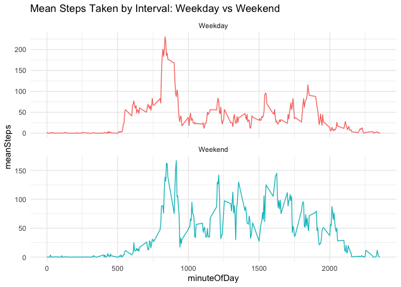

```r
# to use ggplot instead of the default i need to reconstruct them into one dataset:
mean_steps_weekday$dayType <- "Weekday"
mean_steps_weekend$dayType <- "Weekend"
combined_data <- rbind(mean_steps_weekday, mean_steps_weekend)

# Create the plot with facet_wrap, stacking them vertically
ggplot(combined_data, aes(x = minuteOfDay, y = meanSteps)) +
  geom_line(aes(color = dayType)) +
  labs(title = "Mean Steps Taken by Interval: Weekday vs Weekend") +
  facet_wrap(~ dayType, nrow = 2, scales = "free_y") +
  theme_minimal() +
  theme(legend.position = "none")
```